# Exploring the History of Lego

In this project, we will be using different data manipulation techniques from basic Python to explore Lego's history.

*The Rebrickable database includes data on every LEGO set that has ever been sold; the names of the sets, what bricks they contain, what color the bricks are, etc. It might be small bricks, but this is big data! In this project, you will get to explore the Rebrickable database and answer a series of questions related to the history of Lego!*

## 1. Introduction

Everyone loves Lego (unless you ever stepped on one). Did you know by the way that "Lego" was derived from the Danish phrase leg godt, which means "play well"? Unless you speak Danish, probably not.

In this project, we will analyze a fascinating dataset on every single Lego block that has ever been built!

[figure not shown]

```python
# Nothing to do here
```

## 2. Reading Data

A comprehensive database of lego blocks is provided by [Rebrickable](https://rebrickable.com/downloads/). The data is available as csv files and the schema is shown below.

[figure not shown]

Let us start by reading in the colors data to get a sense of the diversity of Lego sets!

```python
# Import pandas
import pandas as pd

# Read colors data
colors = pd.read_csv('datasets/colors.csv')

# Print the first few rows
print(colors.head(10))
```

```
   id            name     rgb is_trans
0  -1         Unknown  0033B2        f
1   0           Black  05131D        f
2   1            Blue  0055BF        f
3   2           Green  237841        f
4   3  Dark Turquoise  008F9B        f
5   4             Red  C91A09        f
6   5       Dark Pink  C870A0        f
7   6           Brown  583927        f
8   7      Light Gray  9BA19D        f
9   8       Dark Gray  6D6E5C        f
```

## 3. Exploring Colors

Now that we have read the `colors` data, we can start exploring it! Let us start by understanding the number of colors available.

```python
# How many distinct colors are available?
print(colors.shape)

# Print num_colors
num_colors = colors.shape[0] # num_colors = colors.rgb.size
print("Available colors: " + str(num_colors))
```

```
(135, 4)
Available colors: 135
```

## 4. Transparent Colors in Lego Sets

The `colors` data has a column named `is_trans` that indicates whether a color is transparent or not. It would be interesting to explore the distribution of transparent vs. non-transparent colors.

```python
# colors_summary: Distribution of colors based on transparency
colors_summary = colors.groupby('is_trans').count()
colors_summary
```

| is_trans | id | name | rgb |
| --- | --- | --- | --- |
| f | 107 | 107 | 107 |
| t | 28 | 28 | 28 |

## 5. Explore Lego Sets

Another interesting dataset available in this database is the `sets` data. It contains a comprehensive list of sets over the years and the number of parts that each of these sets contained.

[figure not shown]

Let us use this data to explore how the average number of parts in Lego sets has varied over the years.

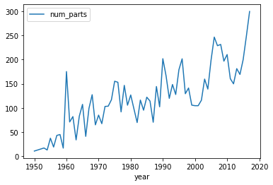

```python
%matplotlib inline
# Read sets data as `sets`
sets = pd.read_csv('datasets/sets.csv')

# Create a summary of average number of parts by year: `parts_by_year`
parts_by_year = sets[['year', 'num_parts']].groupby('year').mean()

# Plot trends in average number of parts by year
parts_by_year.plot()
```

## 6. Lego Themes Over Years

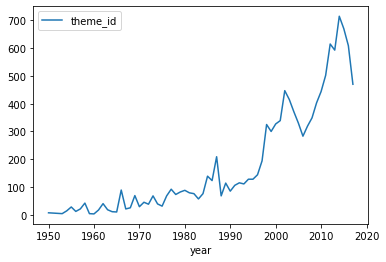

```python
# themes_by_year: Number of themes shipped by year
themes_by_year = sets[['year', 'theme_id']].groupby('year').count()
themes_by_year.plot()
```

## 7. Wrapping It All Up!

Lego blocks offer an unlimited amount of fun across ages. We explored some interesting trends around colors, parts, and themes. Before we wrap up, let's take a closer look at the `themes_by_year` DataFrame you created in the previous step.

```python
# Get the number of unique themes released in 1999
num_themes = themes_by_year.loc[1999, 'theme_id']

# Print the number of unique themes released in 1999
print(num_themes)
```

```
300
```